# TABULAR PLAYGROUND - JULY 2021- EXPLORATORY ANALYSIS OF AIR POLLUTANTS WITH REGRESSION MODELS

```python
'''
applying log scaling to the predictors and targets
'''
def log_scaling(col):
    col = np.log1p(col)
    return col

log_scale = train_eng.copy()
for t in log_scale.columns:
    log_scale[t] = log_scaling(log_scale[t])
```

```python
log_scale.describe()
```

|  | deg_C | relative_humidity | absolute_humidity | sensor_1 | sensor_2 | sensor_3 | sensor_4 | sensor_5 | target_carbon_monoxide | target_benzene | ... | evening | midnight | Friday | Monday | Saturday | Sunday | Thursday | Tuesday | Wednesday | is_weekend |
| --- | --- | --- | --- | --- | --- | --- | --- | --- | --- | --- | --- | --- | --- | --- | --- | --- | --- | --- | --- | --- | --- |
| count | 7111.000000 | 7111.000000 | 7111.000000 | 7111.000000 | 7111.000000 | 7111.000000 | 7111.000000 | 7111.000000 | 7111.000000 | 7111.000000 | ... | 7111.000000 | 7111.000000 | 7111.000000 | 7111.000000 | 7111.000000 | 7111.000000 | 7111.000000 | 7111.000000 | 7111.000000 | 7111.000000 |
| mean | 3.010875 | 3.808586 | 0.727923 | 6.977256 | 6.797553 | 6.731233 | 7.291797 | 6.834473 | 1.031356 | 2.168513 | ... | 0.115784 | 0.115723 | 0.100647 | 0.098328 | 0.098389 | 0.098328 | 0.100647 | 0.098328 | 0.098877 | 0.196608 |
| std | 0.406481 | 0.404368 | 0.198131 | 0.193461 | 0.315017 | 0.323938 | 0.261305 | 0.386188 | 0.429461 | 0.761459 | ... | 0.258789 | 0.258545 | 0.244263 | 0.241821 | 0.241821 | 0.241821 | 0.244263 | 0.241821 | 0.242554 | 0.312470 |
| min | 0.832909 | 2.292535 | 0.181321 | 6.431814 | 5.899897 | 5.741720 | 6.316984 | 5.495938 | 0.095310 | 0.095310 | ... | 0.000000 | 0.000000 | 0.000000 | 0.000000 | 0.000000 | 0.000000 | 0.000000 | 0.000000 | 0.000000 | 0.000000 |
| 25% | 2.766319 | 3.546740 | 0.618370 | 6.836528 | 6.601094 | 6.525103 | 7.186409 | 6.584584 | 0.693147 | 1.704748 | ... | 0.000000 | 0.000000 | 0.000000 | 0.000000 | 0.000000 | 0.000000 | 0.000000 | 0.000000 | 0.000000 | 0.000000 |
| 50% | 3.077312 | 3.877432 | 0.734049 | 6.967438 | 6.819143 | 6.719979 | 7.322576 | 6.834862 | 0.993252 | 2.251292 | ... | 0.000000 | 0.000000 | 0.000000 | 0.000000 | 0.000000 | 0.000000 | 0.000000 | 0.000000 | 0.000000 | 0.000000 |
| 75% | 3.288402 | 4.123903 | 0.877196 | 7.103980 | 7.025627 | 6.917557 | 7.450893 | 7.111267 | 1.335001 | 2.721295 | ... | 0.000000 | 0.000000 | 0.000000 | 0.000000 | 0.000000 | 0.000000 | 0.000000 | 0.000000 | 0.000000 | 0.693147 |
| max | 3.852273 | 4.519612 | 1.172792 | 7.644584 | 7.742228 | 7.851038 | 7.977556 | 7.861573 | 2.602690 | 4.169761 | ... | 0.693359 | 0.693359 | 0.693359 | 0.693359 | 0.693359 | 0.693359 | 0.693359 | 0.693359 | 0.693359 | 0.693147 |

8 rows × 25 columns

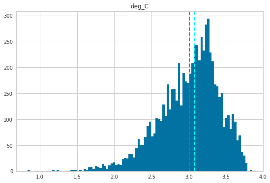

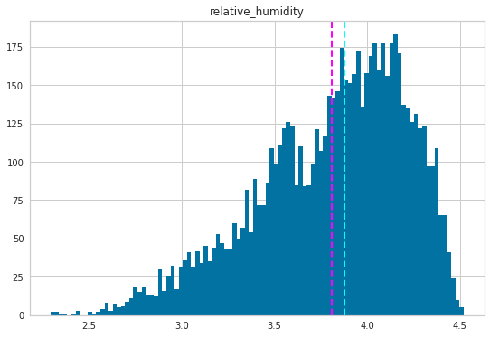

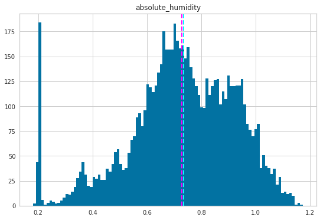

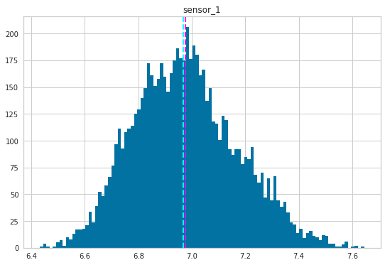

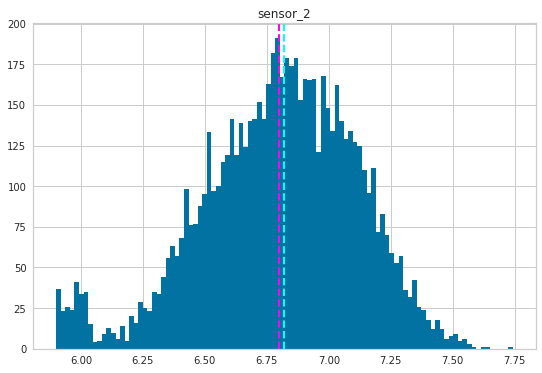

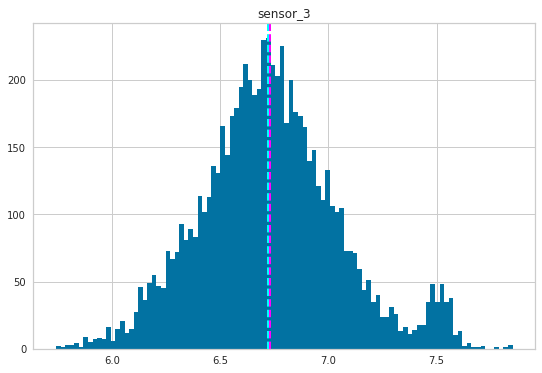

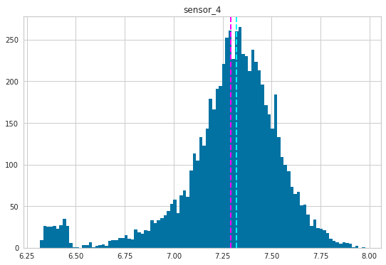

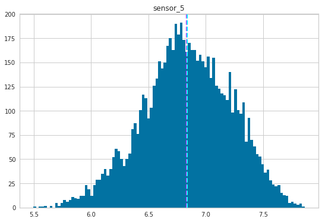

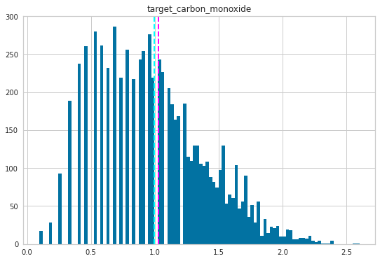

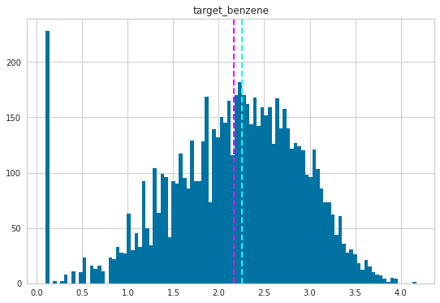

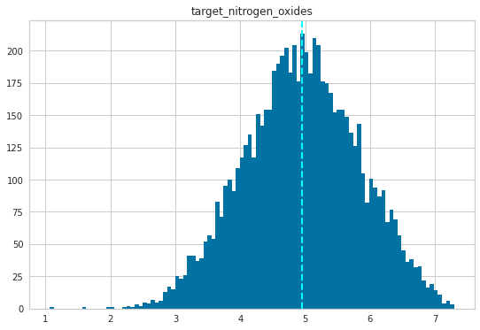

```python
for col in numeric_features:
    fig = plt.figure(figsize=(9, 6))
    ax = fig.gca()
    feature = log_scale[col]
    feature.hist(bins=100, ax = ax)
    ax.axvline(feature.mean(), color='magenta', linestyle='dashed', linewidth=2)
    ax.axvline(feature.median(), color='cyan', linestyle='dashed', linewidth=2)
    ax.set_title(col)
plt.show()
```

```python
from sklearn.preprocessing import StandardScaler

standard_scale = train_eng.copy()
scaler = StandardScaler()
scaled = pd.DataFrame(scaler.fit_transform(standard_scale), columns = train_eng.columns)
```

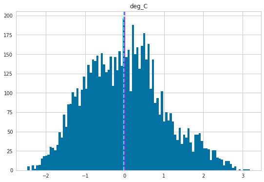

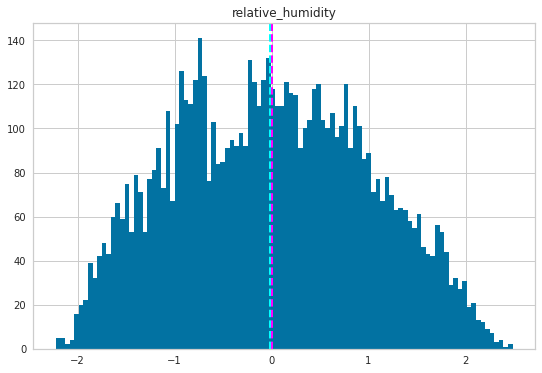

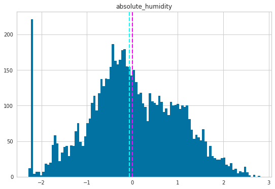

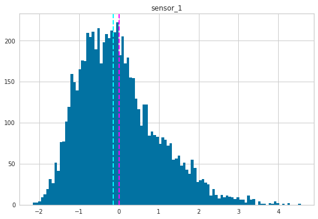

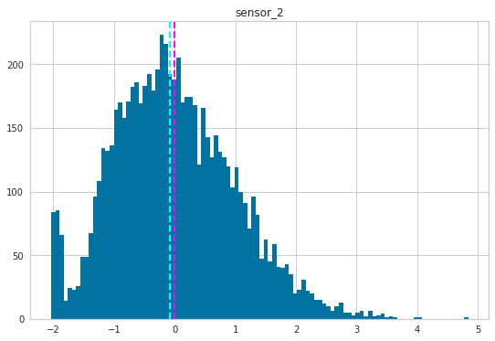

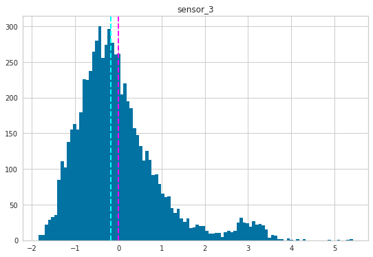

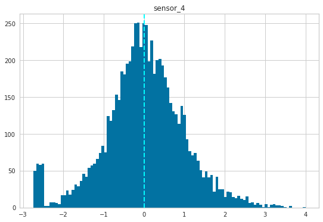

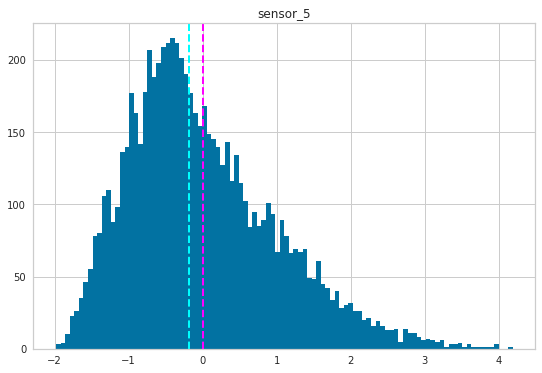

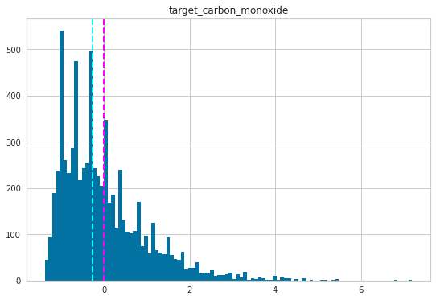

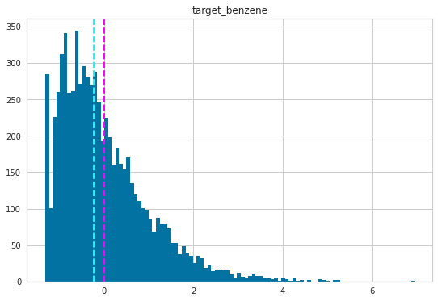

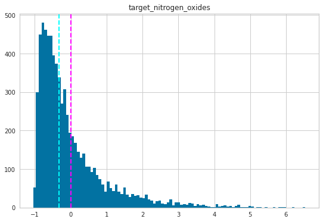

```python
for col in numeric_features:
    fig = plt.figure(figsize=(9, 6))
    ax = fig.gca()
    feature = scaled[col]
    feature.hist(bins=100, ax = ax)
    ax.axvline(feature.mean(), color='magenta', linestyle='dashed', linewidth=2)
    ax.axvline(feature.median(), color='cyan', linestyle='dashed', linewidth=2)
    ax.set_title(col)
plt.show()
```

### Thoughts:

All the distributions are bit on the tail heavy side. Log scaling looks certainly the most plausible to work with as it is closes to normal distribution and the mean and the median are closer to the center.

> **Note**: The distributions are not truly *normal* in the statistical sense, which would result in a smooth, symmetric "bell-curve" histogram with the mean and mode (the most common value) in the center; but they do generally indicate that most of the observations have a value somewhere near the middle.

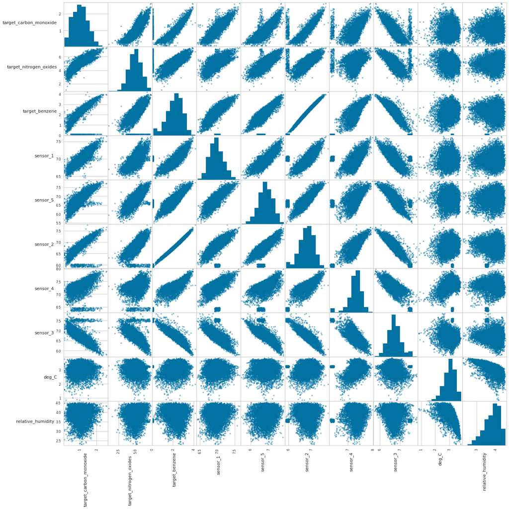

```python
from pandas.plotting import scatter_matrix

attributes = ['target_carbon_monoxide','target_nitrogen_oxides',
              'target_benzene','sensor_1','sensor_5','sensor_2','sensor_4', 'sensor_3','deg_C','relative_humidity']

axes = scatter_matrix(log_scale[attributes], figsize=(18,18))
for ax in axes.flatten():
    ax.xaxis.label.set_rotation(90)
    ax.yaxis.label.set_rotation(0)
    ax.yaxis.label.set_ha('right')

plt.tight_layout()
plt.gcf().subplots_adjust(wspace=0, hspace=0)
plt.show()
```

## Thoughts

Since we decided to use log scale as final method, after plotting scatter matrix only for that scale, there seems to both linear and non linear relationships between the different features.

1. The sensors seems to have a linear relationship with their target variables.
2. The temperature, humidity both have non linear relationships.
3. The target variables have linear relationship with each other.

Lets get the correlation matrix to see if the linear and non linear relations makes sense with pearson correlation analysis

```python
'''correlation of features with CO target variable'''

corr_matrix = log_scale.corr()
corr_matrix['target_carbon_monoxide'].sort_values(ascending=False)
```

```
target_carbon_monoxide    1.000000
sensor_1                  0.870870
target_nitrogen_oxides    0.843404
sensor_5                  0.829337
sensor_2                  0.779981
target_benzene            0.774434
sensor_4                  0.475681
evening                   0.329730
noon                      0.108269
afternoon                 0.100031
Friday                    0.096594
Thursday                  0.084747
Tuesday                   0.062351
Wednesday                 0.052710
morning                   0.049013
deg_C                     0.041945
absolute_humidity        -0.010726
Monday                   -0.027995
relative_humidity        -0.030062
Saturday                 -0.063538
midnight                 -0.081991
Sunday                   -0.206758
is_weekend               -0.209171
dawn                     -0.505413
sensor_3                 -0.707397
Name: target_carbon_monoxide, dtype: float64
```

```python
'''correlation of features with NO target variable'''

corr_matrix['target_nitrogen_oxides'].sort_values(ascending=False)
```

```
target_nitrogen_oxides    1.000000
target_carbon_monoxide    0.843404
sensor_5                  0.778850
sensor_1                  0.711786
sensor_2                  0.652730
target_benzene            0.651093
sensor_4                  0.226679
evening                   0.203325
noon                      0.136201
morning                   0.105208
relative_humidity         0.101113
Friday                    0.077549
afternoon                 0.074427
Thursday                  0.063057
Tuesday                   0.053671
Wednesday                 0.048867
Monday                   -0.021145
Saturday                 -0.045496
midnight                 -0.069243
absolute_humidity        -0.109330
is_weekend               -0.172943
deg_C                    -0.174690
Sunday                   -0.177989
dawn                     -0.450123
sensor_3                 -0.647287
Name: target_nitrogen_oxides, dtype: float64
```

```python
'''correlation of features with benzene target variable'''

corr_matrix['target_benzene'].sort_values(ascending=False)
```

```
target_benzene            1.000000
sensor_2                  0.989710
sensor_5                  0.822993
sensor_4                  0.819966
target_carbon_monoxide    0.774434
sensor_1                  0.743550
target_nitrogen_oxides    0.651093
absolute_humidity         0.341020
evening                   0.242480
deg_C                     0.143921
noon                      0.122983
afternoon                 0.105975
Tuesday                   0.084101
morning                   0.067985
Thursday                  0.054046
Wednesday                 0.031614
Friday                    0.027704
Monday                    0.003599
Saturday                 -0.017511
relative_humidity        -0.053485
midnight                 -0.072257
is_weekend               -0.156263
Sunday                   -0.184428
dawn                     -0.467419
sensor_3                 -0.899791
Name: target_benzene, dtype: float64
```

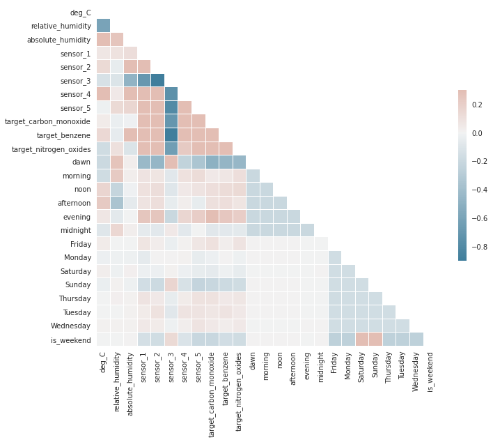

```python
'''
plotting the corrleation matrix with the seaborn heatmap method
'''

import matplotlib.pyplot as plt
import seaborn as sns

mask = np.triu(np.ones_like(corr_matrix, dtype=bool))
f, ax = plt.subplots(figsize=(11, 9))
cmap = sns.diverging_palette(230, 20, as_cmap=True)
sns.heatmap(corr_matrix, mask=mask, cmap=cmap, vmax=.3, center=0,
            square=True, linewidths=.5, cbar_kws={"shrink": .5})
```

## Train a Regression Model

Now that we've explored the data, it's time to use it to train a regression model that uses the features we've identified as potentially predictive to predict the targets. The first thing we need to do is to seperate the train data into train and validation. Since the it is multivariate analysis and there 3 different target variables and one is dependant on the other we need to use them while training, so train_test_split will not work here. So we will randomly split the dataframe into 80/20.

Beginning with a naive linear regression model.

```python
val = log_scale.sample(frac = 0.2)
train = log_scale.drop(val.index)

print(f'train size: {len(train)}, val size: {len(val)}')
```

```
train size: 5689, val size: 1422
```

## LinearRegression()

```python
from sklearn.linear_model import LinearRegression
from sklearn.metrics import mean_squared_error, r2_score


'''
Linear regression first. Although we saw some non linear relationship between features, it is a good starting place to
get an idea and quantify some metrics before moving to more complex models'''


model_dict = {'target_nitrogen_oxides':LinearRegression(),  #Dictionary for 3 different targets with linearregression
             'target_benzene': LinearRegression(),
             'target_carbon_monoxide': LinearRegression()}

for idx_target, target in enumerate(model_dict,1):    #iterate over the dictionary and split the target and predictors
    X_train = train.iloc[:, :-3]
    y_train = train.iloc[:, -idx_target]

    X_test = val.iloc[:, :-3]
    y_test = val.iloc[:, -idx_target]

    model_dict[target].fit(X_train, y_train)
    preds = model_dict[target].predict(X_test)
    rmse = mean_squared_error(y_test,preds)
    r2 = r2_score(y_test,preds)

    print(f'{target}: rmse: {np.sqrt(rmse).round(2)}, r2:  {r2}')   #results
```

```
target_nitrogen_oxides: rmse: 0.0, r2:  1.0
target_benzene: rmse: 0.18, r2:  0.4087527397272016
target_carbon_monoxide: rmse: 0.18, r2:  0.4284852854084843
```

### Decision Tree()

```python
from sklearn.tree import DecisionTreeRegressor

'''Decision Trees can learn with non linear data'''

model_dict = {'target_nitrogen_oxides':DecisionTreeRegressor(),
             'target_benzene': DecisionTreeRegressor(),
             'target_carbon_monoxide': DecisionTreeRegressor()}

for idx_target, target in enumerate(model_dict,1):    #iterate over the dictionary and split the target and predictors
    X_train = train.iloc[:, :-3]
    y_train = train.iloc[:, -idx_target]

    X_test = val.iloc[:, :-3]
    y_test = val.iloc[:, -idx_target]

    model_dict[target].fit(X_train, y_train)
    preds = model_dict[target].predict(X_test)
    rmse = mean_squared_error(y_test,preds)
    r2 = r2_score(y_test,preds)

    print(f'{target}: rmse: {np.sqrt(rmse).round(2)}, r2:  {r2}')
```

```
target_nitrogen_oxides: rmse: 0.0, r2:  1.0
target_benzene: rmse: 0.24, r2:  0.00290895553331183
target_carbon_monoxide: rmse: 0.24, r2:  0.05350032825995843
```

### RandomForestRegressor}()

```python
from sklearn.ensemble import RandomForestRegressor

'''An even better tree model'''


model_dict = {'target_nitrogen_oxides':RandomForestRegressor(),
             'target_benzene': RandomForestRegressor(),
             'target_carbon_monoxide': RandomForestRegressor()}

for idx_target, target in enumerate(model_dict,1):       #iterate over the dictionary and split the target and predictors
    X_train = train.iloc[:, :-3]
    y_train = train.iloc[:, -idx_target]

    X_test = val.iloc[:, :-3]
    y_test = val.iloc[:, -idx_target]

    model_dict[target].fit(X_train, y_train)
    preds = model_dict[target].predict(X_test)
    rmse = mean_squared_error(y_test,preds)
    r2 = r2_score(y_test,preds)

    print(f'{target}: rmse: {np.sqrt(rmse).round(2)}, r2:  {r2}')
```

```
target_nitrogen_oxides: rmse: 0.0, r2:  1.0
target_benzene: rmse: 0.17, r2:  0.4818565637285873
target_carbon_monoxide: rmse: 0.17, r2:  0.49018064876404266
```

So now we've quantified the ability of our model to predict the number of pollutants. But target_nitrogen_oxides having 1.0 is too good to be true and all things points to overfitting. It definitely has *some* predictive power, but we can probably do better!

#### k-Fold implementation and more capable model- CatBoostRegressor

Until now we had an arbitrary split for the training and validation. While random, the prediction capabilities could widely vary for different sample. Instead of relying on one such sample, lets implement kfold validation. CatBoost is a high-performance open source library for gradient boosting on decision trees and could be slightly or even much better than sklearn implementations.

```python
from sklearn.model_selection import TimeSeriesSplit
from catboost import CatBoostRegressor

'''CatBoostRegressor serves as the state of the art for many regression problems'''



SEED = 42     #random seed

model_dict = {'target_nitrogen_oxides':CatBoostRegressor(random_state=SEED,    #model dictionary
                                learning_rate=0.05,
                                depth=8,
                               verbose=False),
             'target_benzene': CatBoostRegressor(random_state=SEED,
                                learning_rate=0.05,
                                depth=8,
                               verbose=False),
             'target_carbon_monoxide': CatBoostRegressor(random_state=SEED,
                                learning_rate=0.05,
                                depth=8,
                               verbose=False)}

splits = 5
kfold = TimeSeriesSplit(n_splits=splits)

for idx_fold, (train_idx,val_idx) in enumerate(kfold.split(train)):   #iterate over the folds and create a random train and val variables
    k_train, k_val = scaled.iloc[train_idx], scaled.iloc[val_idx]

    for idx_target, target in enumerate(model_dict,1):       #iterate over model dictionary
        x_train = k_train.iloc[:,:-3]
        x_val = k_val.iloc[:,:-3]

        y_train = k_train.iloc[:,-idx_target].astype(float)
        y_val = k_val.iloc[:,-idx_target].astype(float)


        model_dict[target].fit(x_train,y_train)      #train
        preds = model_dict[target].predict(x_val)    #predict

        r2 = r2_score(y_val,preds)                    #metrics
        rmse = mean_squared_error(y_val, np.expm1(preds)) ** (1/2)

        print(f'fold:{idx_fold} ; {target}: rmse: {rmse} and r2: {r2}')
    print('\n')
```

```
fold:0 ; target_nitrogen_oxides: rmse: 1.0529544665290886 and r2: 0.9974132121018654
fold:0 ; target_benzene: rmse: 1.201197100617081 and r2: 0.18798240533290678
fold:0 ; target_carbon_monoxide: rmse: 1.0788616944930722 and r2: 0.29493642598948155


fold:1 ; target_nitrogen_oxides: rmse: 1.0355463399824767 and r2: 0.9919394065562662
fold:1 ; target_benzene: rmse: 1.2723163749640798 and r2: 0.017191386726805313
fold:1 ; target_carbon_monoxide: rmse: 1.7465031271362252 and r2: 0.10507687095896012


fold:2 ; target_nitrogen_oxides: rmse: 1.190591651537904 and r2: 0.9991069760430005
fold:2 ; target_benzene: rmse: 1.432105456069224 and r2: 0.3091265990764992
fold:2 ; target_carbon_monoxide: rmse: 1.074027839347575 and r2: 0.26791220420906503


fold:3 ; target_nitrogen_oxides: rmse: 1.0858058566054205 and r2: 0.9981514826829635
fold:3 ; target_benzene: rmse: 0.9404438796719523 and r2: 0.33533835959902725
fold:3 ; target_carbon_monoxide: rmse: 1.2028703149344242 and r2: 0.30973147996458394


fold:4 ; target_nitrogen_oxides: rmse: 1.203806865889381 and r2: 0.9991057498990993
fold:4 ; target_benzene: rmse: 1.08095657271 and r2: 0.3156448589920443
fold:4 ; target_carbon_monoxide: rmse: 0.8902000126305795 and r2: 0.388304039571714
```

Quite decent for a minimal feature engineering given that the top sumbission for the kaggle challenge was ~0.22 when this was made and the test results were unknown. Let's try to streamline the process by using high level libraries like pycaret or AutoML.

Pycaret is a great tool for machine learning and data anaylsis. It's pretty cool how high level libraries for machine learning have matured in the recent years. We can create complex regression model with just few lines of code.

### FineTuning the process with Pycaret

We need to train and evaluate for each indiviudal targets. First, setting up the model with the predictor features and only target variable as carbon monoxide.

```python
from pycaret.regression import setup, compare_models, blend_models, finalize_model,tune_model, predict_model, plot_model


setup_target_carbon_monoxide = setup(data = log_scale, target = 'target_carbon_monoxide', session_id=24,

                  # Ignore features target_benzene and target_nitrogen_oxides from the experiment
                  ignore_features = ['target_benzene','target_nitrogen_oxides'],
                  silent = True
)
```

|  | Description | Value |
| --- | --- | --- |
| 0 | session_id | 24 |
| 1 | Target | target_carbon_monoxide |
| 2 | Original Data | (7111, 25) |
| 3 | Missing Values | False |
| 4 | Numeric Features | 21 |
| 5 | Categorical Features | 1 |
| 6 | Ordinal Features | False |
| 7 | High Cardinality Features | False |
| 8 | High Cardinality Method | None |
| 9 | Transformed Train Set | (4977, 22) |
| 10 | Transformed Test Set | (2134, 22) |
| 11 | Shuffle Train-Test | True |
| 12 | Stratify Train-Test | False |
| 13 | Fold Generator | KFold |
| 14 | Fold Number | 10 |
| 15 | CPU Jobs | -1 |
| 16 | Use GPU | False |
| 17 | Log Experiment | False |
| 18 | Experiment Name | reg-default-name |
| 19 | USI | 22e2 |
| 20 | Imputation Type | simple |
| 21 | Iterative Imputation Iteration | None |
| 22 | Numeric Imputer | mean |
| 23 | Iterative Imputation Numeric Model | None |
| 24 | Categorical Imputer | constant |
| 25 | Iterative Imputation Categorical Model | None |
| 26 | Unknown Categoricals Handling | least_frequent |
| 27 | Normalize | False |
| 28 | Normalize Method | None |
| 29 | Transformation | False |
| 30 | Transformation Method | None |
| 31 | PCA | False |
| 32 | PCA Method | None |
| 33 | PCA Components | None |
| 34 | Ignore Low Variance | False |
| 35 | Combine Rare Levels | False |
| 36 | Rare Level Threshold | None |
| 37 | Numeric Binning | False |
| 38 | Remove Outliers | False |
| 39 | Outliers Threshold | None |
| 40 | Remove Multicollinearity | False |
| 41 | Multicollinearity Threshold | None |
| 42 | Remove Perfect Collinearity | True |
| 43 | Clustering | False |
| 44 | Clustering Iteration | None |
| 45 | Polynomial Features | False |
| 46 | Polynomial Degree | None |
| 47 | Trignometry Features | False |
| 48 | Polynomial Threshold | None |
| 49 | Group Features | False |
| 50 | Feature Selection | False |
| 51 | Feature Selection Method | classic |
| 52 | Features Selection Threshold | None |
| 53 | Feature Interaction | False |
| 54 | Feature Ratio | False |
| 55 | Interaction Threshold | None |
| 56 | Transform Target | False |
| 57 | Transform Target Method | box-cox |

```python
#Train all the regression models available in the library and choose the best ones.
best_target_carbon_monoxide = compare_models(sort = 'RMSLE', n_select = 3)
```

|  | Model | MAE | MSE | RMSE | R2 | RMSLE | MAPE | TT (Sec) |
| --- | --- | --- | --- | --- | --- | --- | --- | --- |
| catboost | CatBoost Regressor | 0.0788 | 0.0121 | 0.1097 | 0.9350 | 0.0565 | 0.1001 | 4.3950 |
| lightgbm | Light Gradient Boosting Machine | 0.0821 | 0.0134 | 0.1155 | 0.9278 | 0.0589 | 0.1039 | 0.2510 |
| xgboost | Extreme Gradient Boosting | 0.0845 | 0.0138 | 0.1174 | 0.9256 | 0.0600 | 0.1061 | 5.8570 |
| et | Extra Trees Regressor | 0.0830 | 0.0139 | 0.1175 | 0.9253 | 0.0603 | 0.1055 | 1.5260 |
| rf | Random Forest Regressor | 0.0865 | 0.0150 | 0.1221 | 0.9193 | 0.0621 | 0.1093 | 2.3780 |
| gbr | Gradient Boosting Regressor | 0.0876 | 0.0153 | 0.1237 | 0.9173 | 0.0629 | 0.1121 | 0.9080 |
| knn | K Neighbors Regressor | 0.1090 | 0.0223 | 0.1492 | 0.8795 | 0.0746 | 0.1338 | 0.0700 |
| ridge | Ridge Regression | 0.1096 | 0.0235 | 0.1531 | 0.8731 | 0.0777 | 0.1402 | 0.0150 |
| lr | Linear Regression | 0.1097 | 0.0235 | 0.1531 | 0.8731 | 0.0778 | 0.1403 | 0.3810 |
| br | Bayesian Ridge | 0.1097 | 0.0235 | 0.1531 | 0.8731 | 0.0778 | 0.1403 | 0.0180 |
| dt | Decision Tree Regressor | 0.1217 | 0.0292 | 0.1709 | 0.8423 | 0.0873 | 0.1473 | 0.0550 |
| huber | Huber Regressor | 0.1154 | 0.0302 | 0.1736 | 0.8371 | 0.0880 | 0.1455 | 0.1160 |
| par | Passive Aggressive Regressor | 0.1307 | 0.0313 | 0.1766 | 0.8312 | 0.0893 | 0.1610 | 0.0230 |
| ada | AdaBoost Regressor | 0.1345 | 0.0301 | 0.1734 | 0.8377 | 0.0910 | 0.1856 | 0.3660 |
| omp | Orthogonal Matching Pursuit | 0.1425 | 0.0392 | 0.1978 | 0.7881 | 0.1000 | 0.1773 | 0.0150 |
| lar | Least Angle Regression | 0.1848 | 0.1131 | 0.2427 | 0.4041 | 0.1111 | 0.2294 | 0.0190 |
| en | Elastic Net | 0.3530 | 0.1865 | 0.4317 | -0.0044 | 0.2158 | 0.4897 | 0.0270 |
| llar | Lasso Least Angle Regression | 0.3530 | 0.1865 | 0.4317 | -0.0044 | 0.2158 | 0.4897 | 0.0150 |
| lasso | Lasso Regression | 0.3530 | 0.1865 | 0.4317 | -0.0044 | 0.2158 | 0.4897 | 0.0160 |

Catboost regressor seems to be the best one in pycaret implementation as well.

```python
#Instead of choosing one, lets ensemble top 10 models

model_target_carbon_monoxide = blend_models(best_target_carbon_monoxide)
```

|  | MAE | MSE | RMSE | R2 | RMSLE | MAPE |
| --- | --- | --- | --- | --- | --- | --- |
| 0 | 0.0776 | 0.0110 | 0.1050 | 0.9375 | 0.0515 | 0.0941 |
| 1 | 0.0762 | 0.0109 | 0.1043 | 0.9397 | 0.0518 | 0.0874 |
| 2 | 0.0810 | 0.0132 | 0.1149 | 0.9278 | 0.0589 | 0.1025 |
| 3 | 0.0812 | 0.0135 | 0.1163 | 0.9335 | 0.0563 | 0.0929 |
| 4 | 0.0804 | 0.0143 | 0.1195 | 0.9265 | 0.0651 | 0.1267 |
| 5 | 0.0803 | 0.0120 | 0.1097 | 0.9379 | 0.0570 | 0.1040 |
| 6 | 0.0753 | 0.0110 | 0.1047 | 0.9387 | 0.0556 | 0.0987 |
| 7 | 0.0829 | 0.0131 | 0.1145 | 0.9236 | 0.0609 | 0.1114 |
| 8 | 0.0803 | 0.0121 | 0.1102 | 0.9340 | 0.0562 | 0.0976 |
| 9 | 0.0741 | 0.0111 | 0.1052 | 0.9421 | 0.0528 | 0.0857 |
| Mean | 0.0789 | 0.0122 | 0.1104 | 0.9341 | 0.0566 | 0.1001 |
| SD | 0.0028 | 0.0012 | 0.0053 | 0.0059 | 0.0040 | 0.0115 |

```python
#Hyperparameter fine tuning

Tuned_model_target_carbon_monoxide  = tune_model(model_target_carbon_monoxide )
```

|  | MAE | MSE | RMSE | R2 | RMSLE | MAPE |
| --- | --- | --- | --- | --- | --- | --- |
| 0 | 0.0768 | 0.0108 | 0.1040 | 0.9387 | 0.0512 | 0.0934 |
| 1 | 0.0760 | 0.0109 | 0.1044 | 0.9395 | 0.0520 | 0.0874 |
| 2 | 0.0806 | 0.0129 | 0.1137 | 0.9293 | 0.0583 | 0.1018 |
| 3 | 0.0804 | 0.0132 | 0.1150 | 0.9351 | 0.0559 | 0.0923 |
| 4 | 0.0799 | 0.0140 | 0.1184 | 0.9279 | 0.0646 | 0.1256 |
| 5 | 0.0798 | 0.0118 | 0.1088 | 0.9389 | 0.0566 | 0.1033 |
| 6 | 0.0752 | 0.0109 | 0.1042 | 0.9393 | 0.0555 | 0.0988 |
| 7 | 0.0824 | 0.0129 | 0.1138 | 0.9246 | 0.0605 | 0.1109 |
| 8 | 0.0796 | 0.0120 | 0.1097 | 0.9346 | 0.0560 | 0.0968 |
| 9 | 0.0734 | 0.0108 | 0.1040 | 0.9433 | 0.0525 | 0.0851 |
| Mean | 0.0784 | 0.0120 | 0.1096 | 0.9351 | 0.0563 | 0.0995 |
| SD | 0.0027 | 0.0011 | 0.0051 | 0.0057 | 0.0039 | 0.0113 |

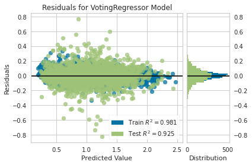

```python
#Plotting the final ensembled models residuals

plot_model(Tuned_model_target_carbon_monoxide)
```

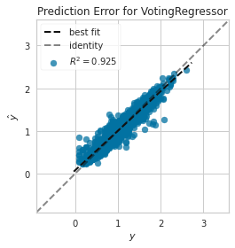

```python
#plotting the fitted line for the prediction

predict_model(Tuned_model_target_carbon_monoxide)
plot_model(Tuned_model_target_carbon_monoxide, plot='error')
```

It is as simple to train a ML model. A r^2 of 0.925 is certainly much better than the best catboost model of 0.4 from sklearns implementation.

### Evaluating on the unseen data.

Predicting on the unseen test data. Needs some manipulation before getting the labels.

```python
#applying log scaling to test data and removing the target variable columns before predicting with the trained model

test_eng = test_eng.drop(['target_carbon_monoxide','target_benzene','target_nitrogen_oxides'], axis=1)
log_scale_test = test_eng.copy()

for t in log_scale_test.columns:
    log_scale_test[t] = log_scaling(log_scale_test[t])
```

```python
test_preds = predict_model(Tuned_model_target_carbon_monoxide,log_scale_test)
test_preds.head()
```

```
Transformation Pipeline and Model Successfully Loaded
```

[output not shown]

5 rows × 23 columns

Alright, it works. Instead of repeating the 5 cells above for every target variable, we will take this oppurtunity to create a single object with pycaret where users can simply input the data and the AirPollutionPrediction() object would train and return the best model. We will also include a predictor function within the object to make it easier for future use.

```python
from pycaret.regression import *


class AirPollutionPrediction():
    def __init__(self,train,test):   #initialize input dataframes
        self.train = train
        self.test = test



    def pycaret_train(self,train,target,ignore_features):   #training method.

        setup(data=train,target=target, session_id=24,
                  ignore_features = ignore_features,
                  silent = True)

        best = compare_models(sort = 'RMSLE', n_select = 3)    #trains several models and returns the best 10 models
        blended = blend_models(estimator_list= best)           #ensembles the best models.
        tuned  = tune_model(blended )                          #hyperparameter fine tunining
        pred_holdout = predict_model(blended)                 #holdout validation
        final_model = finalize_model(blended)


        name = f'airpollutant_{target}'
        save_model(final_model, name)                        #save model with name airpollutant_{labeltype}
        return final_model

    def predict(self,test,model):                            #calls model and predict on unseen test data and plot the same
        pred_esb = predict_model(model, test)
        re = pred_esb['Label']



        return re


    def run(self,train,target,test):                       #run method
        result  = pd.DataFrame()
        targets  = ['target_nitrogen_oxides','target_carbon_monoxide','target_benzene']

        for target in targets:                            #call the train and test functions for dfifferent target variables.

            if target == 'target_nitrogen_oxides':
                ignores = [targets[1],targets[2]]
                model = self.pycaret_train(train,target,ignores)
                result['target_nitrogen_oxides'] = self.predict(test,model)
            elif target == 'target_carbon_monoxide':
                ignores = [targets[0],targets[2]]
                model = self.pycaret_train(train,target,ignores)
                result['target_carbon_monoxide'] = self.predict(test,model)
            elif target == 'target_benzene':
                ignores = [targets[0],targets[1]]
                model = self.pycaret_train(train,target,ignores)
                result['benzene'] = self.predict(test,model)

        return result

    def main(self):                                      #main function. Takes input to begin training with y and pass with n

        print('Train the model: y or n?')
        target = input()
        while target not in ('y','n'):
            print('Enter Valid choice')
            target = input()
            print('Train the model: y or n?')


        if target == 'y':
            predictions = self.run(self.train,target,self.test)
            predictions.to_csv('results.csv')                  #save test predictions to csv
        else:
            pass

    if __name__ == 'main':
        main()
```

```python
pollution = AirPollutionPrediction(train = log_scale, test= log_scale_test)
pollution.main()
```

|  | MAE | MSE | RMSE | R2 | RMSLE | MAPE |
| --- | --- | --- | --- | --- | --- | --- |
| 0 | 0.0696 | 0.0075 | 0.0866 | 0.9875 | 0.0299 | 0.0407 |
| 1 | 0.0714 | 0.0079 | 0.0889 | 0.9851 | 0.0303 | 0.0380 |
| 2 | 0.0682 | 0.0071 | 0.0841 | 0.9877 | 0.0296 | 0.0401 |
| 3 | 0.0695 | 0.0074 | 0.0862 | 0.9875 | 0.0295 | 0.0385 |
| 4 | 0.0662 | 0.0067 | 0.0821 | 0.9880 | 0.0277 | 0.0362 |
| 5 | 0.0705 | 0.0076 | 0.0869 | 0.9877 | 0.0302 | 0.0417 |
| 6 | 0.0732 | 0.0082 | 0.0904 | 0.9856 | 0.0319 | 0.0437 |
| 7 | 0.0678 | 0.0074 | 0.0858 | 0.9871 | 0.0289 | 0.0368 |
| 8 | 0.0651 | 0.0066 | 0.0815 | 0.9885 | 0.0273 | 0.0359 |
| 9 | 0.0686 | 0.0074 | 0.0860 | 0.9883 | 0.0297 | 0.0401 |
| Mean | 0.0690 | 0.0074 | 0.0859 | 0.9873 | 0.0295 | 0.0392 |
| SD | 0.0023 | 0.0004 | 0.0026 | 0.0011 | 0.0013 | 0.0024 |

|  | Model | MAE | MSE | RMSE | R2 | RMSLE | MAPE |
| --- | --- | --- | --- | --- | --- | --- | --- |
| 0 | Voting Regressor | 0.0698 | 0.0076 | 0.0872 | 0.9866 | 0.0296 | 0.0382 |

```
Transformation Pipeline and Model Successfully Saved
```

#### Loading the test predictions

```python
test_results = pd.read_csv('./results.csv', index_col=[0])
final = [log_scale_test, test_results]
final = pd.concat(final,axis=1, join='inner')
```

```python
final.head()
```

|  | deg_C | relative_humidity | absolute_humidity | sensor_1 | sensor_2 | sensor_3 | sensor_4 | sensor_5 | dawn | morning | ... | Monday | Saturday | Sunday | Thursday | Tuesday | Wednesday | is_weekend | target_nitrogen_oxides | target_carbon_monoxide | benzene |
| --- | --- | --- | --- | --- | --- | --- | --- | --- | --- | --- | --- | --- | --- | --- | --- | --- | --- | --- | --- | --- | --- |
| 1 | 1.808289 | 3.964615 | 0.375968 | 7.131299 | 6.763769 | 6.535096 | 6.881206 | 7.447168 | 0.000000 | 0.0 | ... | 0.0 | 0.693359 | 0.0 | 0.0 | 0.0 | 0.0 | 0.693147 | 5.788731 | 0.932186 | 2.116958 |
| 2 | 1.916923 | 3.960813 | 0.384514 | 7.006333 | 6.778785 | 6.543480 | 6.848960 | 7.171503 | 0.693359 | 0.0 | ... | 0.0 | 0.693359 | 0.0 | 0.0 | 0.0 | 0.0 | 0.693147 | 5.733205 | 0.958473 | 2.101631 |
| 3 | 1.791759 | 3.975936 | 0.384786 | 7.039397 | 6.821326 | 6.588376 | 6.919684 | 7.157735 | 0.693359 | 0.0 | ... | 0.0 | 0.693359 | 0.0 | 0.0 | 0.0 | 0.0 | 0.693147 | 5.774099 | 1.009564 | 2.197030 |
| 4 | 1.704748 | 4.069027 | 0.381855 | 6.930886 | 6.732806 | 6.771363 | 6.875232 | 7.041674 | 0.693359 | 0.0 | ... | 0.0 | 0.693359 | 0.0 | 0.0 | 0.0 | 0.0 | 0.693147 | 5.414419 | 0.692009 | 1.978213 |
| 5 | 1.704748 | 4.001864 | 0.389268 | 6.912743 | 6.615396 | 6.819143 | 6.897806 | 6.882232 | 0.693359 | 0.0 | ... | 0.0 | 0.693359 | 0.0 | 0.0 | 0.0 | 0.0 | 0.693147 | 5.265816 | 0.609709 | 1.753950 |

5 rows × 25 columns

### Result thoughts

Okay,Now we can train and call the best model to predict input values easily. The test set metrics could not be quantified because the kaggle challenge was ongoing. I will try to update the quantification if or when the results are released. Thanks for your time.